# 🌲 Above-Ground Biomass & Carbon Stock Mapping from LiDAR

**Author:** Dr. Sonali Sharma  
**Data:** Canopy Height Model (CHM) derived from airborne LiDAR, Helsinki urban neighbourhood  
**Species data:** Luke VMI 2023 national forest species map (open access, Paituli)

## Project Overview

Urban and peri-urban forests are increasingly recognised as critical carbon sinks hence spatially explicit estimate of their carbon stock holds true value. Ground-based field inventories are expensive, slow, and produce point-sample estimates at best.

This notebook demonstrates how **airborne LiDAR combined with national forest inventory species data** can produce a wall-to-wall, spatially explicit above-ground biomass (AGB) and carbon stock map at individual-tree resolution.

**Picks up directly from** `02_lidar_tree_detection.ipynb`, which produced `chm_veg_05m_clean.tif`.

### What this notebook produces

[output not shown]

### Key design decisions

- **Height → DBH bridge** — Repola equations require both height and diameter at breast height (DBH). Since LiDAR gives us height but not DBH directly, we apply species-specific height–diameter relationships calibrated on Finnish NFI plots (Mehtätalo 2004). This introduces uncertainty, but stands as a standard practice in Scandinavian operational AGB mapping.
- **IPCC Tier-1 carbon conversion** — AGB is converted to carbon stock using the factor 0.5 (carbon fraction of dry biomass), consistent with IPCC 2006 Guidelines for National Greenhouse Gas Inventories.

## Data Sources

| Dataset | Source | Licence |
| --- | --- | --- |
| **CHM** (`chm_veg_05m_clean.tif`) | Derived from Helsinki City open LiDAR — [kartta.hel.fi](https://kartta.hel.fi/?link=aw57fg#) | [Helsinki open data licence](https://www.hel.fi/hel2/tietokeskus/julkaisut/pdf/11_05_16_ALLU_avoin_data_lisenssi.pdf) |
| **Species raster** (`maaluokka_vmi1x_1923.tif`) | Luke VMI 2023 national land class / species map, downloaded via [Paituli](https://paituli.csc.fi) | CC BY 4.0 |

> **Reproducibility note:** Run `02_lidar_tree_detection.ipynb` first to generate the CHM. Download the Luke VMI species raster from [Paituli](https://paituli.csc.fi/download.html) (search: *Luke VMI maaluokka*). Update `DATA_DIR` and `SPECIES_PATH` in the configuration cell below.

### Scientific references

[output not shown]

## 0 — Imports & Configuration

```python
# ── Standard library ──────────────────────────────────────────────────────────
import warnings
from pathlib import Path

# ── Geospatial ────────────────────────────────────────────────────────────────
import rasterio
from rasterio.crs import CRS
from rasterio.warp import calculate_default_transform, reproject, Resampling
from rasterio import features as rio_features
import geopandas as gpd
from shapely.geometry import shape, box

# ── Numerical ─────────────────────────────────────────────────────────────────
import numpy as np
from scipy.ndimage import gaussian_filter
from skimage.feature import peak_local_max
from skimage.segmentation import watershed

# ── Tabular ───────────────────────────────────────────────────────────────────
import pandas as pd

# ── Visualisation ─────────────────────────────────────────────────────────────
import matplotlib.pyplot as plt
import matplotlib.patches as mpatches
from matplotlib.colors import Normalize

warnings.filterwarnings('ignore')

# ── FILE PATHS — adjust to your local setup ───────────────────────────────────
DATA_DIR     = Path("E:/Py/3D/CHM")
CHM_PATH     = DATA_DIR / "chm_veg_05m_clean.tif"          # ← from 02_lidar_tree_detection.ipynb
SPECIES_PATH = Path(r"E:/Py/3D/CHM/maaluokka_vmi1x_1923.tif")

OUT_CROWNS        = DATA_DIR / "tree_crowns.gpkg"           # individual crown polygons
OUT_SPECIES_CLIP  = DATA_DIR / "species_clip.tif"           # clipped + reprojected species
OUT_AGB_RASTER    = DATA_DIR / "agb_MgHa.tif"              # AGB map  (Mg ha⁻¹)
OUT_CARBON_RASTER = DATA_DIR / "carbon_MgHa.tif"           # carbon map (Mg C ha⁻¹)
OUT_TREE_TABLE    = DATA_DIR / "tree_agb_table.csv"         # per-tree AGB results

# ── PROCESSING PARAMETERS ─────────────────────────────────────────────────────
SMOOTH_SIGMA      = 1.5   # Gaussian sigma for CHM smoothing (pixels)
MIN_TREE_HEIGHT_M = 5.0   # minimum tree-top height to detect (m)
MIN_DISTANCE_PX   = 5     # minimum pixel spacing between tree tops
PROMINENCE_WINDOW = 12    # local window radius for prominence filter (pixels)
MIN_PROMINENCE    = 0.8   # minimum height above local mean to keep a peak (m)
MIN_CROWN_HEIGHT  = 2.0   # CHM floor for watershed crown mask (m)

print("✓ All imports successful")
print(f"  CHM     : {CHM_PATH}")
print(f"  Species : {SPECIES_PATH}")
```

```
✓ All imports successful
  CHM     : E:\Py\3D\CHM\chm_veg_05m_clean.tif
  Species : E:\Py\3D\CHM\maaluokka_vmi1x_1923.tif
```

## Step 1 — Load and Inspect the Canopy Height Model

```python
with rasterio.open(CHM_PATH) as src:
    chm           = src.read(1).astype(np.float32)
    chm_meta      = src.meta.copy()
    chm_crs       = src.crs
    chm_transform = src.transform
    chm_bounds    = src.bounds
    res_x, res_y  = src.res
    chm_nodata    = src.nodata

# Replace encoded nodata with NaN for consistent masking throughout
if chm_nodata is not None:
    chm[chm == chm_nodata] = np.nan

pixel_area_m2 = res_x * res_y
pixel_area_ha = pixel_area_m2 / 10_000

print("CHM loaded:")
print(f"  Shape        : {chm.shape}  ({chm.shape[1]*res_x:.0f} m × {chm.shape[0]*res_y:.0f} m)")
print(f"  Resolution   : {res_x} m × {res_y} m  |  Pixel area: {pixel_area_m2:.2f} m²")
print(f"  CRS          : {chm_crs}")
print(f"  Bounds       : {chm_bounds}")
print(f"  Height range : {np.nanmin(chm):.1f} m → {np.nanmax(chm):.1f} m")
print(f"  Valid pixels : {np.sum(~np.isnan(chm)):,} of {chm.size:,} "
      f"({np.sum(~np.isnan(chm))/chm.size*100:.1f}% coverage)")
```

```
CHM loaded:
  Shape        : (1000, 1000)  (500 m × 500 m)
  Resolution   : 0.5 m × 0.5 m  |  Pixel area: 0.25 m²
  CRS          : EPSG:3879
  Bounds       : BoundingBox(left=25495500.0, bottom=6682999.999, right=25496000.0, top=6683499.999)
  Height range : 0.5 m → 37.9 m
  Valid pixels : 934,203 of 1,000,000 (93.4% coverage)
```

## Step 2 — Tree Top Detection & Watershed Crown Delineation

```python
# ── 2a. NaN-aware Gaussian smoothing ─────────────────────────────────────────
# Standard gaussian_filter treats NaN as zero, artificially suppressing canopy
# heights near data gaps. Normalised convolution (smoothing numerator and
# denominator separately) preserves correct height values at NoData boundaries.

def nan_aware_gaussian(arr, sigma):
    nan_mask   = np.isnan(arr)
    tmp        = arr.copy(); tmp[nan_mask] = 0.0
    smooth_num = gaussian_filter(tmp, sigma=sigma)
    smooth_den = gaussian_filter((~nan_mask).astype(float), sigma=sigma)
    result     = smooth_num / np.maximum(smooth_den, 1e-6)
    result[nan_mask] = np.nan
    return result

chm_smooth = nan_aware_gaussian(chm, sigma=SMOOTH_SIGMA)

# Detection image: set NaN and sub-threshold pixels to 0
detect_img = chm_smooth.copy()
detect_img[np.isnan(detect_img)]      = 0
detect_img[detect_img < MIN_TREE_HEIGHT_M] = 0

print(f"NaN-aware Gaussian applied (sigma={SMOOTH_SIGMA} px)")
```

```
NaN-aware Gaussian applied (sigma=1.5 px)
```

```python
# ── 2b. Stage 1 — peak local maximum ─────────────────────────────────────────
tree_tops_initial = peak_local_max(
    detect_img,
    min_distance  = MIN_DISTANCE_PX,
    threshold_abs = MIN_TREE_HEIGHT_M,
    exclude_border= False
)
print(f"Stage 1 — peak_local_max : {len(tree_tops_initial):,} candidates")

# ── 2c. Stage 2 — prominence filter ──────────────────────────────────────────
# Retains a peak only if its height exceeds the mean of valid neighbours within
# a local window by at least MIN_PROMINENCE metres.

def filter_by_prominence(chm_img, peaks, window, min_prom):
    keep, half   = [], window // 2
    nrows, ncols = chm_img.shape
    for r, c in peaks:
        h = chm_img[r, c]
        if np.isnan(h) or h <= 0:
            continue
        r0, r1 = max(0, r-half), min(nrows, r+half+1)
        c0, c1 = max(0, c-half), min(ncols, c+half+1)
        local  = chm_img[r0:r1, c0:c1]
        valid  = local[np.isfinite(local) & (local > 0)]
        if len(valid) and (h - valid.mean()) >= min_prom:
            keep.append([r, c])
    return np.array(keep, dtype=int) if keep else np.empty((0, 2), dtype=int)

tree_tops = filter_by_prominence(
    chm_smooth, tree_tops_initial, PROMINENCE_WINDOW, MIN_PROMINENCE
)

rows_t, cols_t = tree_tops[:, 0], tree_tops[:, 1]
top_heights    = chm[rows_t, cols_t]
xs_t, ys_t    = rasterio.transform.xy(chm_transform, rows_t, cols_t, offset="center")
xs_t, ys_t    = np.array(xs_t), np.array(ys_t)

print(f"Stage 2 — prominence filter : {len(tree_tops):,} trees retained "
      f"({len(tree_tops_initial)-len(tree_tops):,} false peaks removed)")
print(f"  Height — min {top_heights.min():.1f} m | "
      f"median {np.median(top_heights):.1f} m | max {top_heights.max():.1f} m")
```

```
Stage 1 — peak_local_max : 4,001 candidates
Stage 2 — prominence filter : 4,001 trees retained (0 false peaks removed)
  Height — min 6.7 m | median 28.6 m | max 37.7 m
```

```python
# ── 2d. Watershed crown delineation ──────────────────────────────────────────
# Each tree top becomes a seed marker. Watershed grows crown regions outward from each seed, constrained to pixels above MIN_CROWN_HEIGHT.

markers = np.zeros(chm.shape, dtype=np.int32)
for idx, (r, c) in enumerate(zip(rows_t, cols_t), start=1):
    markers[r, c] = idx

crown_mask   = (~np.isnan(chm)) & (chm >= MIN_CROWN_HEIGHT)
chm_for_ws   = chm_smooth.copy()
chm_for_ws[np.isnan(chm_for_ws)] = 0

labels = watershed(-chm_for_ws, markers=markers, mask=crown_mask)

print(f"Watershed complete — {labels.max():,} crown segments")
```

```
Watershed complete — 4,001 crown segments
```

```python
# ── 2e. Vectorise crown raster → GeoDataFrame ─────────────────────────────────
# rasterio.features.shapes converts each connected integer region to a polygon.
# Per-crown CHM statistics (mean/max height, area) are computed directly from the label array — faster than zonal_stats on large rasters.

shapes_gen = rio_features.shapes(
    labels.astype(np.int32),
    mask=(labels > 0).astype(np.uint8),
    transform=chm_transform
)

geoms, crown_ids = [], []
for geom_dict, val in shapes_gen:
    geoms.append(shape(geom_dict))
    crown_ids.append(int(val))

crowns = gpd.GeoDataFrame({"crown_id": crown_ids}, geometry=geoms, crs=chm_crs)

# Height stats per crown using the watershed label mask
h_mean_list, h_max_list = [], []
for cid in crowns["crown_id"]:
    pix  = chm[labels == cid]
    pix  = pix[~np.isnan(pix)]
    h_mean_list.append(float(np.mean(pix)) if len(pix) else np.nan)
    h_max_list.append(float(np.max(pix))  if len(pix) else np.nan)

crowns["h_mean_m"]      = h_mean_list
crowns["h_max_m"]       = h_max_list
crowns["crown_area_m2"] = crowns.geometry.area

# Remove crowns with no valid height (data gaps within watershed region)
crowns = crowns.dropna(subset=["h_mean_m"]).copy()
crowns = crowns[crowns["h_mean_m"] > 0].reset_index(drop=True)

crowns.to_file(OUT_CROWNS, driver="GPKG")

print(f"Crown polygons created : {len(crowns):,}")
print(f"  Area   : {crowns.crown_area_m2.min():.1f} m² → {crowns.crown_area_m2.max():.1f} m²  "
      f"(median {crowns.crown_area_m2.median():.1f} m²)")
print(f"  Height : {crowns.h_mean_m.min():.1f} m → {crowns.h_mean_m.max():.1f} m  "
      f"(median {crowns.h_mean_m.median():.1f} m)")
print(f"  Saved  → {OUT_CROWNS}  (open directly in QGIS / ArcGIS)")
```

```
Crown polygons created : 4,001
  Area   : 3.2 m² → 323.2 m²  (median 47.8 m²)
  Height : 4.2 m → 32.5 m  (median 21.2 m)
  Saved  → E:\Py\3D\CHM\tree_crowns.gpkg  (open directly in QGIS / ArcGIS)
```

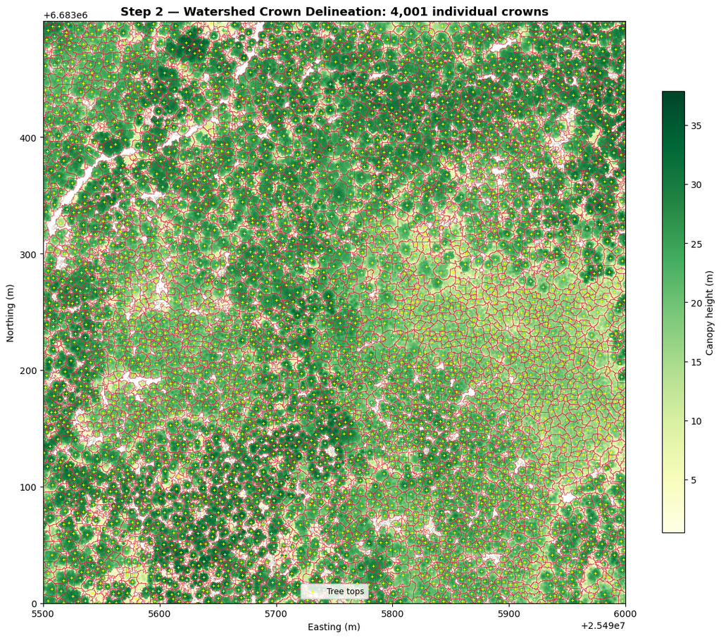

```python
# ── Crown delineation map ─────────────────────────────────────────────────────
fig, ax = plt.subplots(figsize=(12, 10))

im = ax.imshow(
    chm, cmap="YlGn",
    extent=[chm_bounds.left, chm_bounds.right, chm_bounds.bottom, chm_bounds.top],
    origin="upper"
)
crowns.boundary.plot(ax=ax, color="crimson", linewidth=0.5, alpha=0.7)
ax.scatter(xs_t, ys_t, s=6, c="yellow", marker="+", linewidths=0.8, label="Tree tops")

plt.colorbar(im, ax=ax, fraction=0.03, label="Canopy height (m)")
ax.set_title(f"Step 2 — Watershed Crown Delineation: {len(crowns):,} individual crowns",
             fontweight="bold", fontsize=13)
ax.set_xlabel("Easting (m)"); ax.set_ylabel("Northing (m)")
ax.legend(fontsize=9); ax.ticklabel_format(style="plain")
plt.tight_layout(); plt.show()
```